# PDX Energy Spatial Regression Methods

Alec Trusty

November 6, 2017

## Introduction

The purpose of this report is to highlight my methods in developing a spatial regression model of average annual energy use at the census block group level with various structural and sociodemographic explanatory variables.

First, I load in the required R packages for the analysis:

```r
require(dplyr)
require(foreign)
require(rpostgis)
require(RPostgreSQL)
require(sp)
require(spdep)
require(rgeos)
require(leaflet)
require(car)
require(plotly)
require(latticeExtra)
require(rgdal)
require(pander)
options(stringsAsFactors = F, scipen = 999)
panderOptions("round",6)
setwd("/home/atrusty/SUPR/Energy_Research/Energy_Burden/SR_Transfer/")
```

## Data Clean-Up

```r
cbg <- readOGR("Energy_Burden/Metro_EnergyBurden_11817.shp")
#Calculate density and remove the lowest density block groups
cbg$cbg_area <- sapply(slot(cbg, "polygons"), slot, "area") #Create an area column
cbg <- subset(cbg, cbg$cbg_area < 5.0e+07 & cbg$cbg_area > 1e+06) #visually removed the large and very small block groups
cbg <- subset(cbg, cbg$sfr_nt > 40) # Subset CBGs with less than 40 SFR (As Chang et al did)
cbg <- subset(cbg, cbg$TOTexp15 > 600 & cbg$TOTexp15 < 2000)

#Impute Medians
# There Shouldn't be many NA's
medePuter <- function(x){
  x<-as.numeric(as.character(x)) #first convert each column into numeric if it is from factor
  x[is.na(x)] =median(x, na.rm=TRUE) #convert the item with NA to median value from the column
  x #display the column
}

cbg@data <- as.data.frame(apply(cbg@data,2,medePuter)) #Imputes medians for all of the missing independent variables
```

## Normality

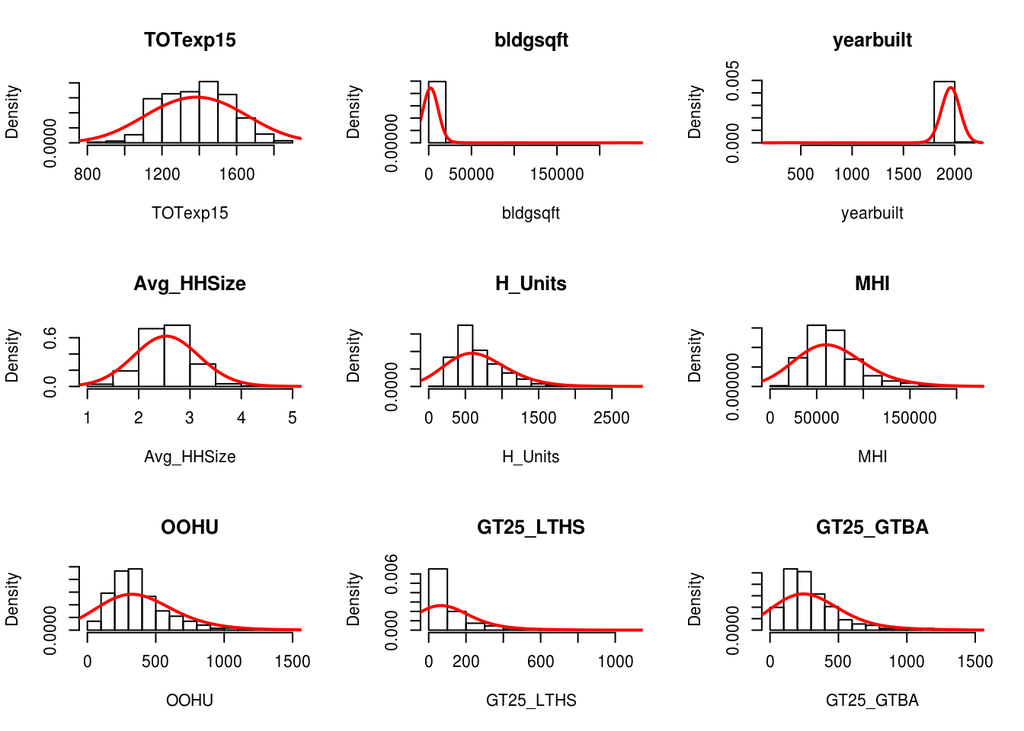

```r
vars<-c("bldgsqft", "yearbuilt", "Avg_HHSize","H_Units", "MHI", "OOHU", "GT25_LTHS","GT25_GTBA", "Pop_Under1", "Pop_65Over", "Pop_White", "Pop_Black", "Pop_Hisp", "gis_acres", "mfr_n", "u_tot")

par(mfrow=c(3,3))

#Making plots for all variables:
invisible(lapply(c("TOTexp15", vars[1:8]), function(x){
  hist(cbg@data[,x],main=paste0(x),xlab=x,freq=F)
  lines(density(cbg@data[,x],bw=sd(cbg@data[,x])),col="red",lwd=2)
}))
```

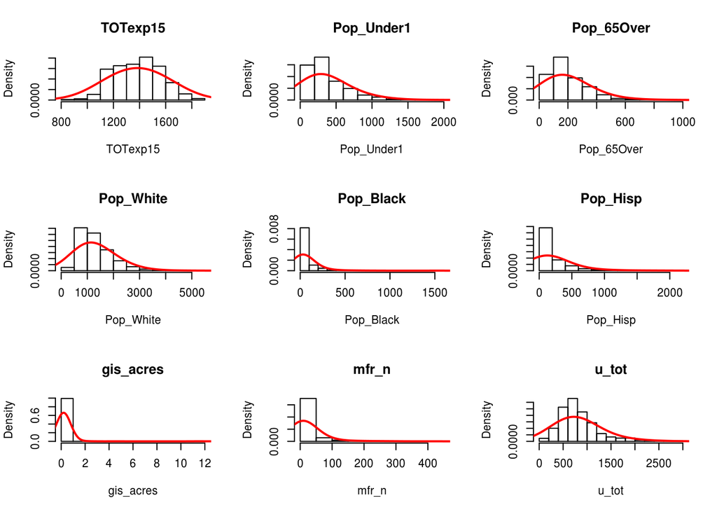

```r
par(mfrow=c(3,3))

#Making plots for all variables:
invisible(lapply(c("TOTexp15", vars[9:16]), function(x){
  hist(cbg@data[,x],main=paste0(x),xlab=x,freq=F)
  lines(density(cbg@data[,x],bw=sd(cbg@data[,x])),col="red",lwd=2)
}))
```

## Explanatory Variable Clean-Up

```r
cbg <- subset(cbg, cbg$yearbuilt > 1800) #Anything with an average age of 1800 or older probably isn't accurate..

cbg$log_bldgsqft <- log(1+cbg$bldgsqft)
cbg$log_GT25_LTHS <- log(1+cbg$GT25_LTHS)
cbg$log_GT25_GTBA<- log(1+cbg$GT25_GTBA)
cbg$log_Under18 <- log(1+cbg$Pop_Under1)
cbg$log_Over65 <- log(1+cbg$Pop_65Over)
cbg$log_Black  <- log(1+cbg$Pop_Black)
cbg$log_Hisp <- log(1+cbg$Pop_Hisp)
cbg$log_acres <- log(1+cbg$gis_acres)
cbg$log_mfrn <- log(1+cbg$mfr_n)
```

Explanatory variable distribution after log transformation:

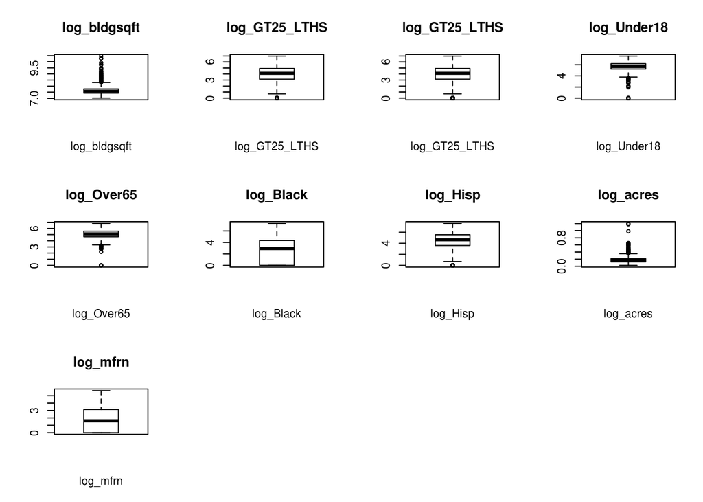

```r
bpvars <- c("log_bldgsqft"
        , "log_GT25_LTHS"
        , "log_GT25_LTHS"
        , "log_Under18"
        , "log_Over65"
        , "log_Black"
        , "log_Hisp"
        , "log_acres"
        , "log_mfrn")

par(mfrow=c(3,4))
invisible(lapply(bpvars, function(x){
  boxplot(cbg@data[,x],main=paste0(x),xlab=x)
}))
```

Log transformation did not ameliorate the skewed distribution of many explanatory variables. Average bldgsqft is still has a ton of outliers… Since we know building size is very important, lets remove some of those outliers.

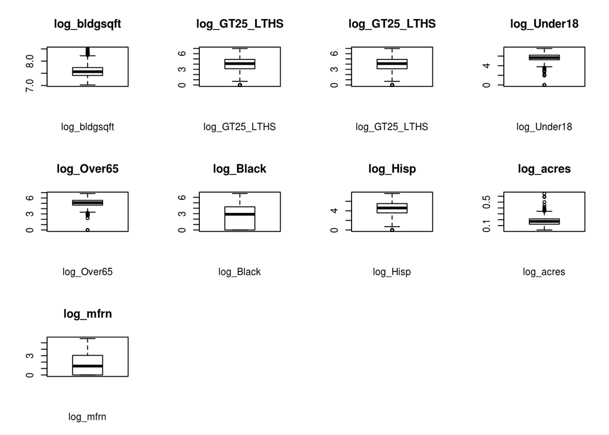

```r
cbg_redu <- subset(cbg, cbg$bldgsqft < 5000)


par(mfrow=c(3,4))
invisible(lapply(bpvars, function(x){
  boxplot(cbg_redu@data[,x],main=paste0(x),xlab=x)
}))
```

Removing outlying block group sample sizes and average building sizes:

```r
cbg_redu <- subset(cbg_redu, cbg_redu$u_tot > 300 & cbg_redu$u_tot < 1300) # Block groups within similar range of utility samples
```

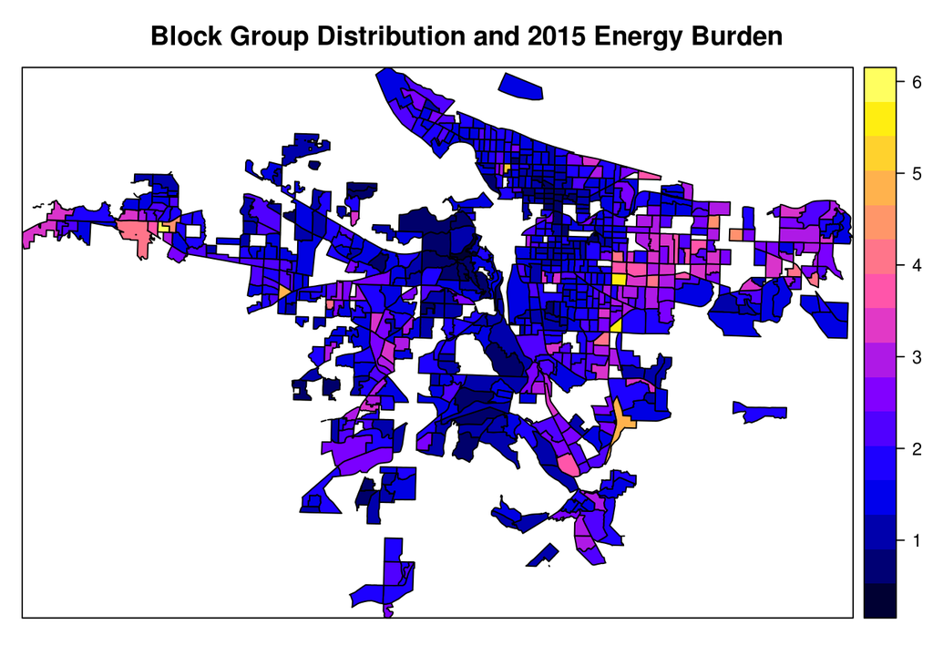

```r
spplot(cbg_redu, zcol="burden", main = "Block Group Distribution and 2015 Energy Burden") #Map it just for funzies
```

## Correlation

Now that we’ve got a cleaner dataset, let’s assess the correlation between total average annual energy use of a block group and our explanatory variables.

```r
vars2<-c("log_bldgsqft", "Avg_HHSize","H_Units", "MHI", "OOHU", "log_GT25_LTHS","log_GT25_GTBA", "log_Under18", "log_Over65", "Pop_White", "log_Black", "log_Hisp", "log_acres", "log_mfrn")

#Assessing Correlation:
tl_cor<-cor(cbg_redu@data[,c("TOTexp15",vars2)])[,1]

tl_cor<-data.frame(Variable=names(tl_cor),r = as.vector(tl_cor));tl_cor
```

```
##         Variable           r
## 1       TOTexp15  1.00000000
## 2   log_bldgsqft  0.27055212
## 3     Avg_HHSize  0.30203016
## 4        H_Units  0.07387317
## 5            MHI  0.38850944
## 6           OOHU  0.36410415
## 7  log_GT25_LTHS -0.03727259
## 8  log_GT25_GTBA -0.01371440
## 9    log_Under18  0.31518582
## 10    log_Over65  0.36523255
## 11     Pop_White  0.27221918
## 12     log_Black -0.23165115
## 13      log_Hisp -0.02069062
## 14     log_acres  0.69847470
## 15      log_mfrn -0.42151344
```

Looks like H_Units and LTHS, GTBA, log_Hisp.

```r
cbg_redu <- cbg_redu[,c("TOTexp15", "log_bldgsqft", "yearbuilt", "Avg_HHSize", "MHI", "OOHU", "log_Under18", "log_Over65", "Pop_White", "log_Black", "log_acres", "log_mfrn")]
```

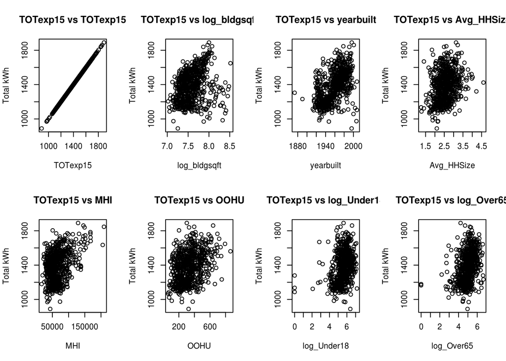

```r
finvars <- c("log_bldgsqft", "yearbuilt", "Avg_HHSize", "MHI", "OOHU", "log_Under18", "log_Over65", "Pop_White", "log_Black", "log_acres", "log_mfrn")

par(mfrow=c(2,4))

#Scatter Plots for All Variables:
invisible(lapply(c("TOTexp15", finvars[1:7]), function(x) {
  plot(cbg_redu@data$TOTexp15 ~ cbg_redu@data[,x],main=paste0("TOTexp15 vs ", x),xlab=x,ylab="Total kWh")
}))
```

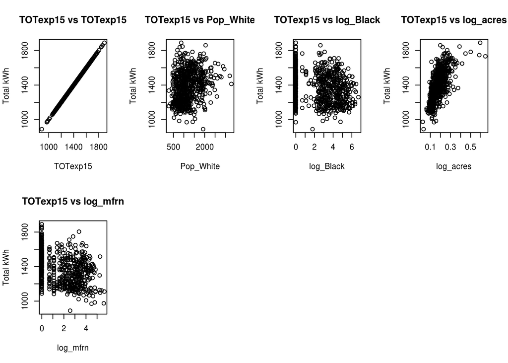

```r
par(mfrow=c(2,4))

#Scatter plots for all Variables:
invisible(lapply(c("TOTexp15", finvars[8:11]), function(x) {
  plot(cbg_redu@data$TOTexp15 ~ cbg_redu@data[,x],main=paste0("TOTexp15 vs ", x),xlab=x,ylab="Total kWh")
}))
```

## OLS Regression

```r
ols <- lm(TOTexp15~., data = cbg_redu)
pander(summary(ols))
```

|  | Estimate | Std. Error | t value | Pr(>\|t\|) |
| --- | --- | --- | --- | --- |
| **(Intercept)** | -3579 | 427.4 | -8.373 | 0 |
| **log_bldgsqft** | 83.92 | 18.44 | 4.551 | 0.000006 |
| **yearbuilt** | 1.959 | 0.2065 | 9.487 | 0 |
| **Avg_HHSize** | 34.12 | 11.42 | 2.989 | 0.002903 |
| **MHI** | 0.00116 | 0.00018 | 6.443 | 0 |
| **OOHU** | -0.08982 | 0.04154 | -2.162 | 0.03094 |
| **log_Under18** | 9.499 | 7.651 | 1.241 | 0.2149 |
| **log_Over65** | 34.21 | 6.459 | 5.295 | 0 |
| **Pop_White** | 0.01224 | 0.01259 | 0.9725 | 0.3311 |
| **log_Black** | -7.941 | 1.92 | -4.137 | 0.00004 |
| **log_acres** | 1036 | 71.03 | 14.58 | 0 |
| **log_mfrn** | -28.71 | 2.816 | -10.2 | 0 |

Fitting linear model: TOTexp15 ~ .

| Observations | Residual Std. Error | $R^2$ | Adjusted $R^2$ |
| --- | --- | --- | --- |
| 697 | 94.6 | 0.7189 | 0.7144 |

```r
car::vif(ols)
```

```
## log_bldgsqft    yearbuilt   Avg_HHSize          MHI         OOHU
##     1.800119     1.559162     2.020087     1.911939     2.540253
##  log_Under18   log_Over65    Pop_White    log_Black    log_acres
##     2.754129     1.857481     2.938404     1.186748     1.807910
##     log_mfrn
##     1.617078
```

Reduced Model:

```r
sfmod.redu <- lm(TOTexp15~
                 + I(2017 - yearbuilt)
                 + log_bldgsqft
                 + Avg_HHSize
                 + MHI
                 + log_Black
                 + log_Over65
                 + log_acres
                 + log_mfrn, data= cbg_redu)
pander(summary(sfmod.redu))
```

|  | Estimate | Std. Error | t value | Pr(>\|t\|) |
| --- | --- | --- | --- | --- |
| **(Intercept)** | 334.3 | 134.6 | 2.484 | 0.01322 |
| **I(2017 - yearbuilt)** | -1.956 | 0.2022 | -9.675 | 0 |
| **log_bldgsqft** | 93.96 | 17.97 | 5.228 | 0 |
| **Avg_HHSize** | 45.12 | 9.116 | 4.95 | 0.000001 |
| **MHI** | 0.000957 | 0.000158 | 6.057 | 0 |
| **log_Black** | -8.06 | 1.903 | -4.235 | 0.000026 |
| **log_Over65** | 30.81 | 5.403 | 5.702 | 0 |
| **log_acres** | 1040 | 70.92 | 14.67 | 0 |
| **log_mfrn** | -28.25 | 2.794 | -10.11 | 0 |

Fitting linear model: TOTexp15 ~ +I(2017 - yearbuilt) + log_bldgsqft + Avg_HHSize + MHI + log_Black + log_Over65 + log_acres + log_mfrn

| Observations | Residual Std. Error | $R^2$ | Adjusted $R^2$ |
| --- | --- | --- | --- |
| 697 | 94.83 | 0.7163 | 0.713 |

```r
car::vif(sfmod.redu)
```

```
## I(2017 - yearbuilt)        log_bldgsqft          Avg_HHSize
##            1.487982            1.701026            1.281560
##                 MHI           log_Black          log_Over65
##            1.463643            1.160764            1.293032
##           log_acres            log_mfrn
##            1.793212            1.584391
```

RMSE:

```r
sqrt(mean(sfmod.redu$residuals^2))
```

```
## [1] 94.21995
```

AIC:

```r
AIC(sfmod.redu)
```

```
## [1] 8334.611
```

*OLS Results:*

## Spatial Regression

*Spatial Weights:* Creating a weights matrix with K-Nearest Neighbors and 5 neighbors to create a matrix from census block group centroids:

```r
tl_point<-gCentroid(cbg_redu,byid=T)

nb <-  knn2nb(knearneigh(tl_point, k = 5))

nb_lines<-spTransform(nb2lines(nb, proj4string = cbg_redu@proj4string, coords = coordinates(tl_point)), CRS("+proj=longlat +datum=WGS84"))
leaflet() %>% addProviderTiles(providers$OpenStreetMap) %>%
  addCircleMarkers(data=spTransform(tl_point,CRS("+proj=longlat +datum=WGS84"))
                   ,weight=2
                   ,color="black"
                   ,fillColor = "grey"
                   ,fillOpacity = 0.15
                   ,opacity= 1
                   ,radius=4) %>%
  addPolylines(data=nb_lines,color="red",weight=2)
```

[interactive chart not shown]

Assessing the correlation between each observation’s residual and the mean value of it’s neighbors residuals. There appears to be a positive spatial trend:

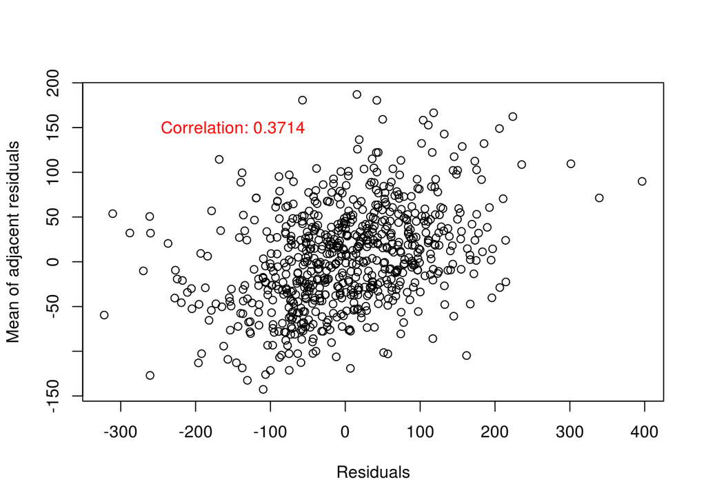

```r
#Creating Spatial lag and plotting
cbg_redu$resid <- sfmod.redu$residuals
resnb <- sapply(nb, function(x) mean(sfmod.redu$residuals[x]))
plot(sfmod.redu$residuals, resnb, xlab ='Residuals', ylab = 'Mean of adjacent residuals')
text(-150,150,paste0("Correlation: ", round(cor(cbg_redu$resid, resnb), 4)), col="red")
```

Testing spatial autocorrelation of the OLS residuals:

```r
weights <- nb2listw(nb)
moran.mc(cbg_redu$resid, weights, 999)
```

```
##
##  Monte-Carlo simulation of Moran I
##
## data:  cbg_redu$resid
## weights: weights
## number of simulations + 1: 1000
##
## statistic = 0.22095, observed rank = 1000, p-value = 0.001
## alternative hypothesis: greater
```

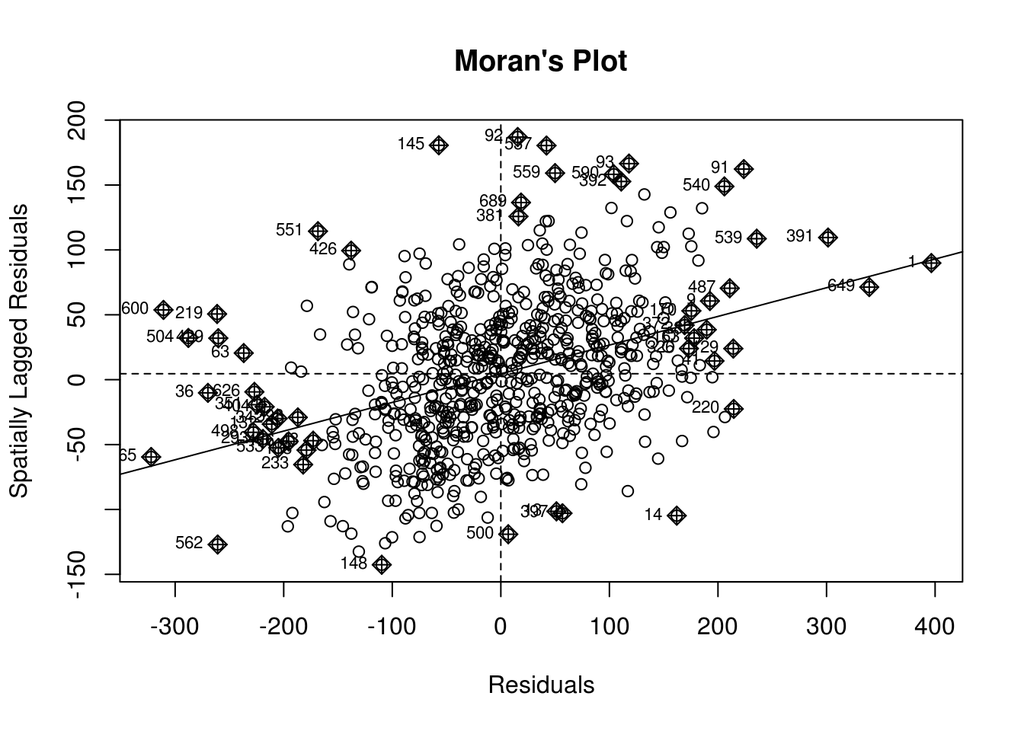

```r
moran.plot(cbg_redu$resid, weights, main = "Moran's Plot", xlab = "Residuals", ylab = "Spatially Lagged Residuals")
```

The residuals of the reduced OLS model are spatially autocorrelated, suggesting that a spatial regression model is necessary. Now we need to determine whether a spatial error or lag model would be more appropriate:

```r
lm.LMtests(sfmod.redu, listw=weights)
```

```
##
##  Lagrange multiplier diagnostics for spatial dependence
##
## data:
## model: lm(formula = TOTexp15 ~ +I(2017 - yearbuilt) + log_bldgsqft
## + Avg_HHSize + MHI + log_Black + log_Over65 + log_acres +
## log_mfrn, data = cbg_redu)
## weights: weights
##
## LMErr = 93.45, df = 1, p-value < 0.00000000000000022
```

## Spatial Error Model

Calculating a spatial error regression model based off of the reduced OLS model:

```r
sem <- errorsarlm(TOTexp15~
                 + I(2017 - yearbuilt)
                 + log_bldgsqft
                 + Avg_HHSize
                 + MHI
                 + log_Black
                 + log_Over65
                 + log_acres
                 + log_mfrn, data= cbg_redu, weights)
summary(sem)
```

```
##
## Call:
## errorsarlm(formula = TOTexp15 ~ +I(2017 - yearbuilt) + log_bldgsqft +
##     Avg_HHSize + MHI + log_Black + log_Over65 + log_acres + log_mfrn,
##     data = cbg_redu, listw = weights)
##
## Residuals:
##       Min        1Q    Median        3Q       Max
## -326.3216  -52.4374   -2.1244   54.6805  316.9326
##
## Type: error
## Coefficients: (asymptotic standard errors)
##                         Estimate   Std. Error z value
## (Intercept)         592.59404060 132.70787231  4.4654
## I(2017 - yearbuilt)  -0.96782491   0.25728296 -3.7617
## log_bldgsqft         62.08847797  17.56164017  3.5355
## Avg_HHSize           32.65281392   8.98042352  3.6360
## MHI                   0.00107450   0.00016637  6.4584
## log_Black            -3.96448548   1.83494072 -2.1606
## log_Over65           20.72920197   4.90055641  4.2300
## log_acres           894.52779599  73.93922663 12.0981
## log_mfrn            -21.57052187   2.57376846 -8.3809
##                                  Pr(>|z|)
## (Intercept)               0.0000079918430
## I(2017 - yearbuilt)             0.0001688
## log_bldgsqft                    0.0004071
## Avg_HHSize                      0.0002769
## MHI                       0.0000000001058
## log_Black                       0.0307299
## log_Over65                0.0000233723457
## log_acres           < 0.00000000000000022
## log_mfrn            < 0.00000000000000022
##
## Lambda: 0.60202, LR test value: 105.93, p-value: < 0.000000000000000222
## Approximate (numerical Hessian) standard error: 0.046983
##     z-value: 12.813, p-value: < 0.000000000000000222
## Wald statistic: 164.19, p-value: < 0.000000000000000222
##
## Log likelihood: -4104.341 for error model
## ML residual variance (sigma squared): 7051, (sigma: 83.97)
## Number of observations: 697
## Number of parameters estimated: 11
## AIC: 8230.7, (AIC for lm: 8334.6)
```

SEM RMSE is slightly lower than the OLS:

```r
sqrt(mean(sem$residuals^2))
```

```
## [1] 83.97043
```

AIC is slightly lower for the spatial model:

```r
AIC(sem)
```

```
## [1] 8230.681
```

```r
#plot(sem$fitted.values~cbg_redu$TOTkwh15, xlab = "Observed 2015 Total kWh Values", ylab = "Fitted SEM Values")
#abline(lm(sem$fitted.values~cbg_redu$TOTkwh15), col="red", lwd=2)
#text(15000,25000,paste0("R-squared: ", #round(summary(lm(sem$fitted.values~cbg_redu$TOTkwh15))$adj.r.square,4)))
```

*Normality in Residuals:*

```r
## Testing Normality in Residuals
shapiro.test(sem$residuals) #indicates residuals are not normaly distributed.
```

```
##
##  Shapiro-Wilk normality test
##
## data:  sem$residuals
## W = 0.99299, p-value = 0.002368
```

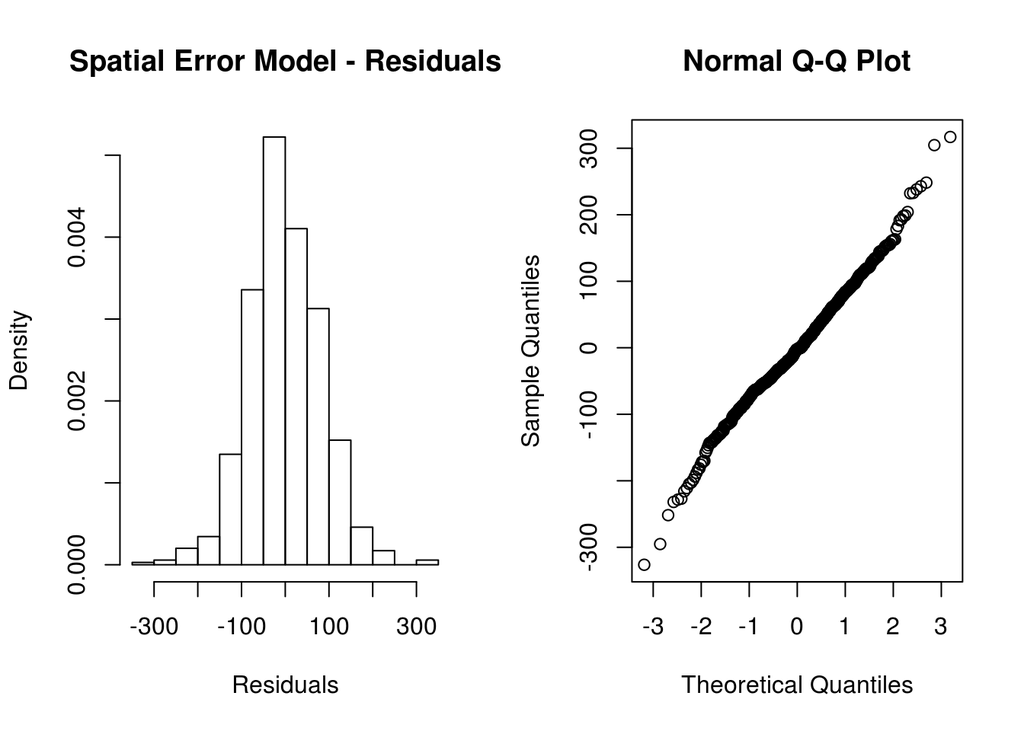

```r
#Check Qnorm
par(mfrow=c(1,2))
hist(sem$residuals, breaks=20, main = "Spatial Error Model - Residuals", xlab = "Residuals", freq = F)
qqnorm(sem$residuals)
```

*Assessing Heteroskedasticity:*

There could be a slight relationship between the fitted values and residuals:

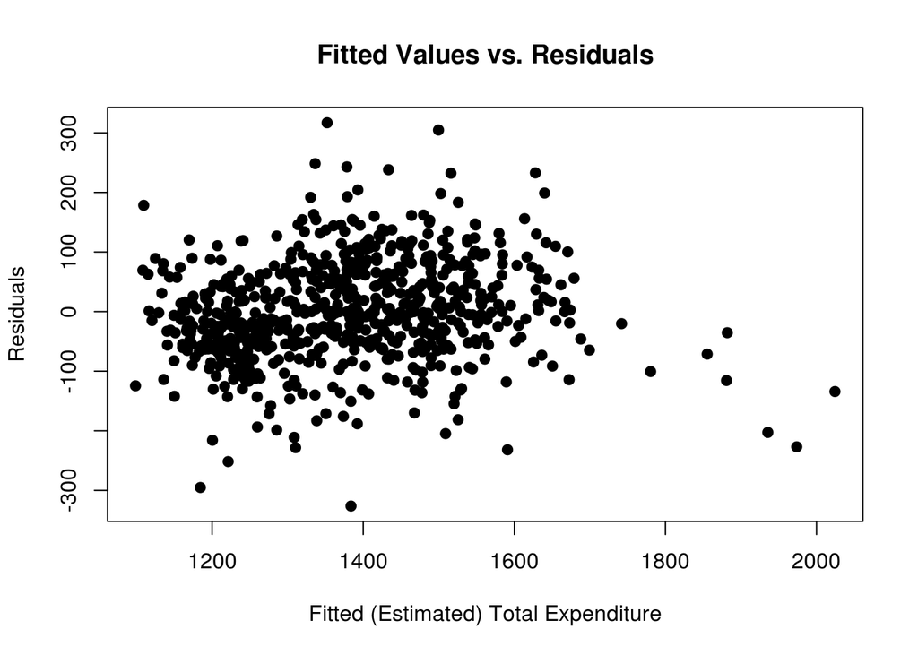

```r
plot(sem$residuals~sem$fitted.values, main = "Fitted Values vs. Residuals", xlab = "Fitted (Estimated) Total Expenditure", ylab = "Residuals", pch = 19)
```

*Assessing Spatial Autocorrelation of the Residuals:*

```r
# Spatial autocorrelation of residuals
moran.mc(sem$residuals, weights, 999)
```

```
##
##  Monte-Carlo simulation of Moran I
##
## data:  sem$residuals
## weights: weights
## number of simulations + 1: 1000
##
## statistic = -0.03419, observed rank = 67, p-value = 0.933
## alternative hypothesis: greater
```

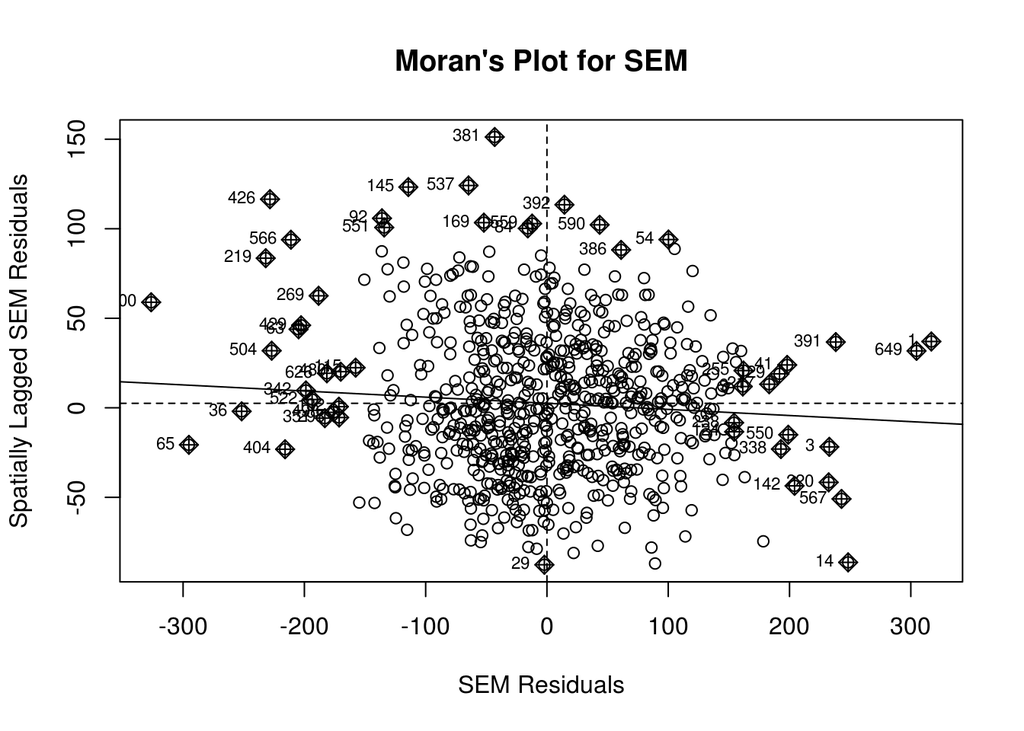

```r
moran.plot(sem$residuals, weights, main = "Moran's Plot for SEM", xlab = "SEM Residuals", ylab = "Spatially Lagged SEM Residuals")
```

## Discussion

*Key Takeaways:*

*Energy Burden:*